# Git for Everyone

An Introduction to Version Control and GitHub

Jared Frazier

Modelling of Atmospheric Processes Department  
Leibniz Institute of Atmospheric Physics

2026-03-13

## Precursors

#### Slides

- Go to the slides since there are lots of clickable links:  
  [jfdev001.github.io/talks/git-for-everyone/index.html](https://jfdev001.github.io/talks/git-for-everyone/index.html#/title-slide)

#### Hands-On Materials

- We’ll use this repository for the exercises:  
  github.com/jfdev001/git-for-everyone-miniweather

#### Behavior

- Ask questions whenever they arise!
- I will make mistakes, though I’ll try my best not to.

## Structure

#### Objectives

- Motivate version control and code collaboration tools.
- Introduce Git commands (plus mental models).
- Introduce GitHub (branches, issues, pull requests/merging).

#### Style

- Mix teaching and practical exercises.
- Ideally, you should have a computer with a text editor/IDE, terminal, and browser open.

## Setup

### Git

#### Windows

- If you are on Windows, select one of the standalone installers (most likely x64) from [install on Windows](https://git-scm.com/install/windows). The default settings are fine.

#### Linux + macOS

- In a terminal, check that `which git` returns a path, otherwise see [install on Linux](https://git-scm.com/install/linux) or [install on macOS](https://git-scm.com/install/mac), respectively.

### GitHub

- If you don’t already have an account, go to [Sign up for GitHub](https://github.com/signup) and go to Appendix: SSH Keys with GitHub if you want to be able to `push` to your repositories.
- Go to the workshop repository and star/fork (top right corner) it:  
  github.com/jfdev001/git-for-everyone-miniweather

# Intro to Git

## What is Git

- A version control system developed by Linus Torvalds (creator of Linux).
- Record the history of file changes over time.
- For each revision/snapshot (aka commit) tell:  
  **Who** changed **what**, **when**, and **why**.
- Intended for text files and **small** datasets (<100 MB).
- Fundamentally **not** for large file storage, see [git-lfs](https://git-lfs.com/), [dvc](https://doc.dvc.org/), etc instead.

## Why You Should Use Git

- Wednesday 22 Jan 2026 11:45 `viz_my_data.py`
- Thursday 23 Jan 2026 14:23 `viz_my_data_v1.py`
- Friday 24 Jan 2026 23:45 `viz_my_data_final_v2_stable.py`

## Basic Commands

- `git init`
  - Create an empty Git repository.
- `git clone <repo url> [<dir>]`
  - Clone a repo into a new directory.

```bash
$ # Alternatively, replace url with your forked url
$ git clone git@github.com:jfdev001/git-for-everyone-miniweather.git
Cloning into 'git-for-everyone-miniweather'...
remote: Enumerating objects: 2200, done.
remote: Counting objects: 100% (2200/2200), done.
remote: Compressing objects: 100% (618/618), done.
remote: Total 2200 (delta 1594), reused 2176 (delta 1574), pack-reused 0 (from 0)
Receiving objects: 100% (2200/2200), 8.44 MiB | 379.00 KiB/s, done.
Resolving deltas: 100% (1594/1594), done.
```

## Basic Commands

- `git init`
  - Create an empty Git repository.
- `git add <filepath>`
  - Stage changes you want to record.
- `git clone <repo url> [<dir>]`
  - Clone a repo into a new directory.
- `git status`
  - List files Git has (not) added.

```bash
$ cd git-for-everyone-miniweather
$ touch NEW_FILE.txt
$ git add ./
$ git status
On branch main
Your branch is up to date with 'origin/main'.

Changes to be committed:
  (use "git restore --staged <file>..." to unstage)
        new file:   NEW_FILE.txt
```

## Basic Commands

- `git init`
  - Create an empty Git repository.
- `git add <filepath>`
  - Stage changes you want to record.
- `git commit [-m "short message here"]`
  - Commit changes to history with message.

```bash
$ git commit -m "add a new file"
[main 8f07f0c] add a new file
 1 file changed, 0 insertions(+), 0 deletions(-)
 create mode 100644 NEW_FILE.txt
```

- `git clone <repo url> [<dir>]`
  - Clone a repo into a new directory.
- `git status`
  - List files Git has (not) added.
- `git log`
  - Show Git history (i.e., commits).

```bash
$ git log
commit 8f07f0cacba3518219d5630d8a95b291ff4ebe3e (HEAD -> main)
Author: Jared Frazier <cscidev001@gmail.com>
Date:   Thu Mar 12 10:45:47 2026 +0100

    add a new file

commit 9584a0cf4f360a50e0981debc7e0256d0e39aadb (origin/main, origin/HEAD)
Author: Jared Frazier <frazier@iap-kborn.de>
Date:   Wed Mar 11 15:39:32 2026 +0100

    add docker pull instructions
```

## Basic Commands

- `git init`
  - Create an empty Git repository.
- `git add <filepath>`
  - Stage changes you want to record.
- `git commit [-m "short message here"]`
  - Commit changes to history with message.
- `git push <remote> <branch>`
  - Send local changes to remote repo.
- `git clone <repo url> [<dir>]`
  - Clone a repo into a new directory.
- `git status`
  - List files Git has (not) added.
- `git log`
  - Show Git history (i.e., commits).

```bash
$ git push
Enumerating objects: 4, done.
Counting objects: 100% (4/4), done.
Delta compression using up to 12 threads
Compressing objects: 100% (2/2), done.
Writing objects: 100% (3/3), 274 bytes | 274.00 KiB/s, done.
Total 3 (delta 1), reused 1 (delta 0), pack-reused 0
remote: Resolving deltas: 100% (1/1), completed with 1 local object.
To github.com:jfdev001/git-for-everyone-miniweather.git
   9584a0c..8f07f0c  main -> main
```

## Exercise

A colleague has written a Fortran application that simulates fluid-dynamic flows:

- github.com/jfdev001/git-for-everyone-miniweather

If you have an account, then fork (upper right corner) the repository and `clone` your fork.

If you do not have an account, just `clone` my repository.

- `git clone <repo url>`
- `git add`
- `git status`
- `git commit [-m "your message here"]`
- `git push`
  - Won’t work if you didn’t fork
- `git log`
- If there are Python scripts, are there dependencies? (hint: add `requirements.txt`)
- Is there a script in `README.md` that could be moved into a new file (hint: bottom of `README.md`)?
- PnetCDF is a dependency, what if this generates large files? (hint: patterns in `.gitignore` aren’t added to Git history)
- Ask questions if you’re lost!

## How does Git work

- Each time you `commit` work, Git stores it as a `diff`.
  - Shows specific lines of a file and how they are changed (`+`/`-`)
  - This is what the command `git diff` shows *before* staging, if you want. to see the `diff`s for staged (i.e., after `git add`) files, do `git diff --staged`.
- `diff`s are stored in a tree, by reconstructing `diff`s you can reconstruct files, and thus the “snapshot” of your files at a particular state of development.

```
$ echo "This is some new text" >> NEW_FILE.txt
$ git diff
diff --git a/NEW_FILE.txt b/NEW_FILE.txt
index e69de29..10ee18b 100644
--- a/NEW_FILE.txt
+++ b/NEW_FILE.txt
@@ -0,0 +1 @@
+This is some new text
```

## Git Workflow: Revisited

# Intro to GitHub

## What is GitHub

- Stores Git repositories online
- Helps developers collaborate on code
- Provides tools for project management

[figure not shown]

## Issues

- Creating issues can be useful for keeping track of work.
- Subsequent commits (in pull requests, more on this later) can reference a particular issue(s).
- Generally you open issues in main repository, but opening them in your fork is fine.

## Exercise

- What sort of improvements could you think of adding to the `miniweather` simulation?
- Open an issue in either your fork or in my repository if you don’t have a fork!
  - To open an issue in your fork, go to Settings > General then search Issues and enable them.
- Hints:
  - Different spatial discretization schemes?
  - CUDA implementation?
  - Different governing equations?

## Branches

- We have only used the `main` branch for all commits.

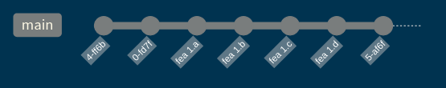

- A more standard approach is to create a branch dedicated to a particular feature or set of changes, then you merge back into main when completed.

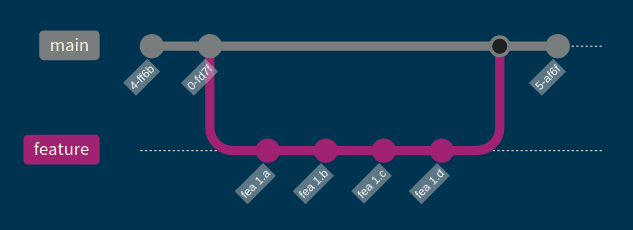

- `git branch <branch name>`
  - Create new branch from current branch.
- `git checkout <branch name>`
  - Move to different branch.
- `git merge <branch name>`
  - Tie the target branch back into the *current* branch.
  - e.g., `git merge feature`

## Branches

Branches facilitate concurrent feature development and project organization.

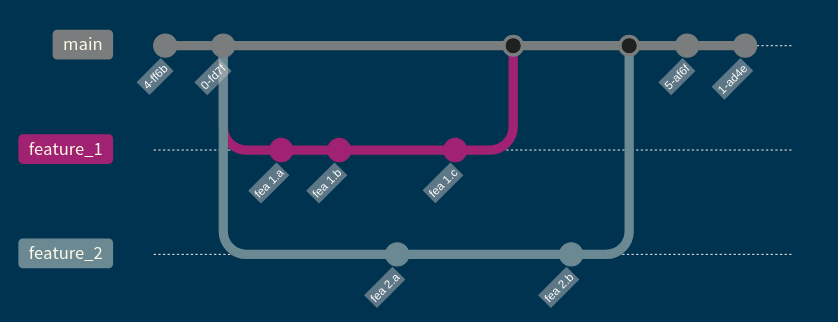

## Exercise

- We want to add a script that cleans/deletes the `build_output` directory.
- Create a branch and add a script (Bash, Python, etc.) to `miniweather/build/` called `clean_build_output` that does this for us.
- Make sure to `git add` and then `commit` your changes.
- `push` your new branch to your remote repository.
- Switch back the `main` branch and inspect the `git log` and `git branch`s.
- `git branch [<branch name>]`
- `git checkout <branch name>`
- `git add`
- `git commit`
- `git push -u origin <new branch name>`

## Pull Requests

- A graphical way to merge branches into `main` on GitHub.
- Can be linked back to GitHub issues, thus improving development organization.
- Method of tracking progress (open a PR after first push) and discussion.
- Should include description of what you’ve done and why you did it.

## Exercise

From branch(es) you pushed in the previous exercise open a pull request to either:

- The `main` branch of my repository.
- The `main` branch of your fork.

Then try and merge what you’ve done.

If there are `merge conflicts` try to resolve them.

## Git Workflow: The Finale

# Summary

- Git is not just a series of backups, it facilitates collaborative software development and clean version tracking.
- Inspect the status and commit history of a repository.
- Use branches for each additional feature/improvement you work on.
- GitHub (and GitLab) provide complementary features to Git:
  - Remote copy of your local Git repository.
  - Issues.
  - Pull requests.
  - Graphical branch merging.

# Git Rabbit Hole

- `git merge` (preserve commit history)
- `git rebase` (graft commit on tip of other branch)
- `git worktree` (two branches “active” at the same time)
- `git filter-repo` (for altering history, e.g., remove large files)
- `git cherry-pick` (take part of other commits)
- `git commit --amend` (change old commit messages)
- `git reset --soft HEAD~<ncommits>` (squash commits)
- [Code Refinery Lessons](https://coderefinery.org/lessons/), [Pro Git Book](https://git-scm.com/book/en/v2), open source contribution guidelines
- …

[figure not shown]

# A Warning

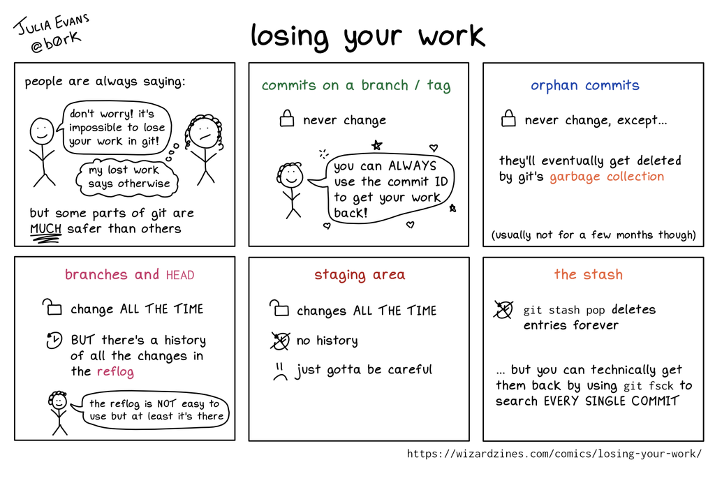

# Thanks!

Get in touch:

Jared Frazier

jfdev001

[jfdev001.github.io](https://jfdev001.github.io/)

[jared-frazier-797590188](https://www.linkedin.com/in/jared-frazier-797590188/)

jaredfrazierapplications@gmail.com

# Appendix

## SSH Keys with GitHub

- This allows you to clone URLs that look like `git@github.com[<repo>].git`
- It also allows you to push to your own repositories.
- In *Git Bash* on Windows or a terminal on Linux/macOS:

```bash
# It's more secure to passphrase protect your SSH key, but up to you...
# for an empty passphrase, just hit enter after calling ssh-keygen
ssh-keygen -t ed25519 -f ~/.ssh/id_github_ed25519

cat ~/.ssh/id_github_ed25519.pub
# ^^ copy the above public key
# GitHub.com > Top Right Corner > Settings > SSH & GPG Keys > New SSH key
# then paste the public key above into the form on GitHub

# there are cleaner ways to do this, but activate your ssh agent like so:
echo 'eval $(ssh-agent -s)' >> ~/.bash_profile
echo "ssh-add ~/.ssh/id_github_ed25519" >> ~/.bash_profile
source ~/.bash_profile

# verify that you can connect to GitHub
# NOTE: The first time you do this, SSH will prompt you to save the fingerprint
# of the host, just hit yes and ignore the warnings.
# The result of this command should be "You've successfully authenticated"
ssh -T git@github.com
```

## Git/GitHub Contribution Sample Workflow

```bash
# Fork the repository on GitHub first (e.g.,
# git@github.com:mygithubuser/miniWeather.git

# clone your fork locally
git clone git@github.com:mygithubuser/miniWeather.git
cd miniWeather

# create a new branch for your contribution
# recommended naming scheme (issue number may not be applicable):
# <myname>/<issue-number>-<feature-description>
git checkout -b myname/42-add-weather-parser

# make your code changes, then stage them
git add .

# commit with a clear message
git commit -m "Add weather parser for METAR data"

# push the branch to your fork
git push -u origin myname/42-add-weather-parser

# go to your fork on GitHub and open a Pull Request (PR)
# GitHub will usually show a "Compare & pull request" button
# if your fork goes out of sync with the upstream, just click on "Sync fork" on
# GitHub, and then do `git pull` locally
```